# Dívida alta exige mais que uma fotografia

Cinco economias · dívida bruta e saldo primário · Fiscal Monitor, abril/2026

Diretoria de Pesquisa Aplicada

## A reunião exige comparar estoque e fluxo no mesmo recorte

- **Pergunta:** o que dívida bruta e saldo primário revelam sobre Brasil, México, Chile, Índia e Indonésia?
- **Premissas da comparação:** mesma edição, mesmo ano de referência e unidade comum.
  - A fotografia usa **2025**; as séries de 2000–2029 mostram o contexto temporal.
  - O recorte é uma seleção para a reunião, não representa todas as economias emergentes.

A resposta descreve posições fiscais. Qualquer afirmação de sustentabilidade exige uma análise adicional.

## As duas medidas respondem a perguntas distintas

| Medida | Código do CSV | Leitura |
| --- | --- | --- |
| Dívida bruta do governo geral | `GGXWDG_NGDP` | Estoque em % do PIB |
| Saldo primário do governo geral | `GGXONLB_NGDP` | Fluxo antes de juros; positivo = superávit |

## O nível de 2025 resulta de trajetórias distintas

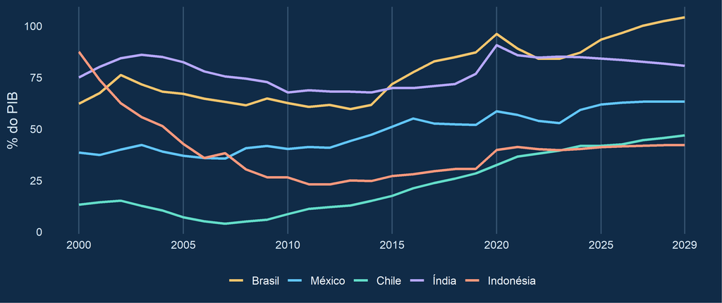

Figura 1: Dívida bruta, % do PIB · 2000–2029 · fonte: CSV-contrato, FM-2026-04.

## Em 2025, o Brasil tem a maior dívida do recorte

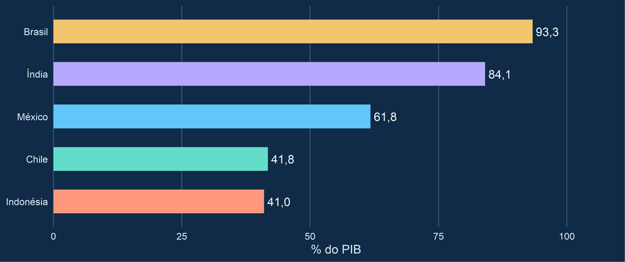

Figura 2: Dívida bruta, % do PIB · 2025 · fonte: CSV-contrato, FM-2026-04.

## O saldo primário muda de sinal ao longo do período

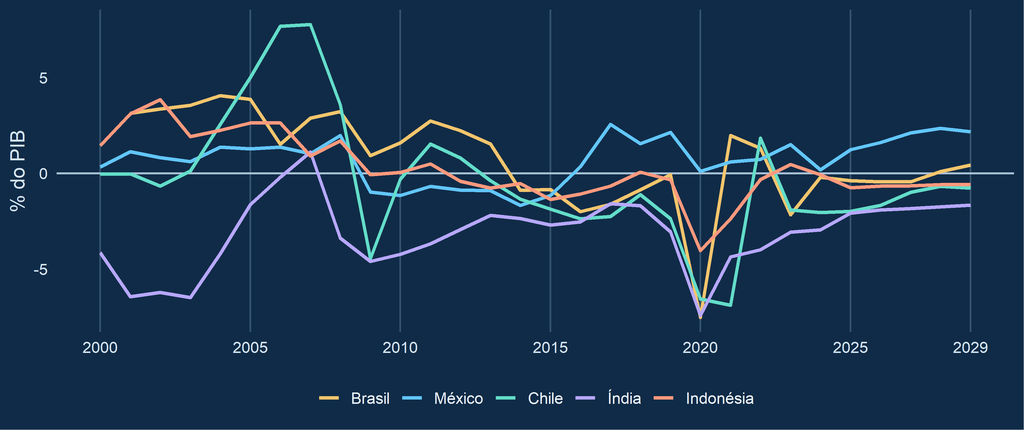

Figura 3: Saldo primário, % do PIB · 2000–2029 · positivo = superávit · fonte: CSV-contrato, FM-2026-04.

## Em 2025, só o México registra superávit primário

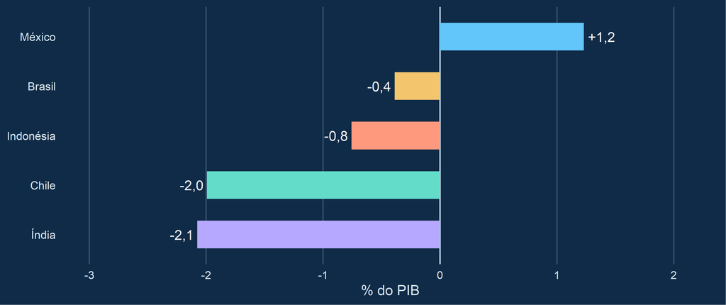

Figura 4: Saldo primário, % do PIB · 2025 · positivo = superávit · fonte: CSV-contrato, FM-2026-04.

## No Brasil, a leitura conjunta amplia o diagnóstico

**93,3%**

Dívida bruta / PIB em 2025

**-0,4%**

Saldo primário / PIB em 2025

- **Evidência:** no recorte de cinco países, o Brasil tem o maior estoque de dívida e saldo primário negativo em 2025.
- **Interpretação:** as duas medidas descrevem uma posição fiscal; não provam, sozinhas, se a dívida é sustentável.

## Estoque e fluxo não formam uma escala única de risco

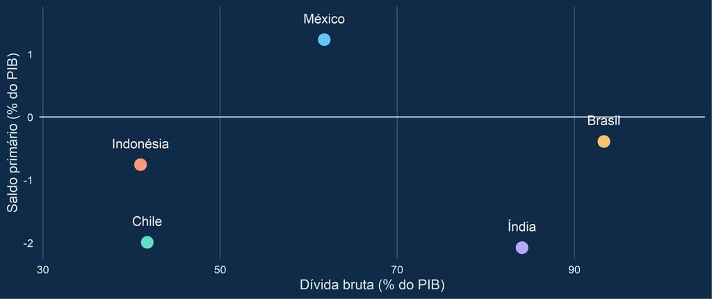

Figura 5: Dívida bruta (x) e saldo primário (y), % do PIB · 2025 · fonte: CSV-contrato, FM-2026-04.

## O primário sozinho não testa sustentabilidade

**1 · Estoque**

A dívida herdada define o ponto de partida.

**2 · Fluxos e condições**

Primário, juros e crescimento afetam a trajetória; ajustes entre estoque e fluxo também podem importar.

**3 · Risco e resposta**

O *Fiscal Monitor* ressalta pressões de juros, financiamento e incerteza. Uma recomendação requer cenários e cobertura verificada.

O par de séries desta apresentação é uma **triagem comparável**, não uma análise de sustentabilidade.

## A conclusão depende de três verificações

- **Status temporal:** o CSV não distingue observado de estimado; confirmar o status da série antes de chamar 2025 de dado realizado.
- **Calendário:** a Índia é apresentada em ano fiscal nas notas metodológicas do FMI.
- **Cobertura:** as notas apontam diferenças nacionais de abrangência; para o México, descrevem setor público sem governos subnacionais.

**Encaminhamento à Diretoria:** usar a comparação para selecionar perguntas; validar cobertura e construir cenários antes de recomendar uma trajetória fiscal.

## Cada gráfico pode ser rastreado até a edição

- **Dados:** `fm_weo_cache.csv`, vintage `FM-2026-04`, dois códigos do contrato.
- **Reprodução:** `baixar_fm.R --offline` → CSV → Quarto; conferir com `validar_contrato.py`.
- **Documentos:** [Fiscal Monitor, abril/2026](https://www.imf.org/-/media/files/publications/fiscal-monitor/2026/april/english/text.pdf), sumário executivo e cap. 1; [apêndice metodológico](https://www.imf.org/-/media/files/publications/fiscal-monitor/2026/april/english/msa.pdf), “Data and Conventions”.
- **Site:** [portal da apresentação](https://fiscal-monitor-2026.netlify.app/) · [painel de exploração](https://fiscal-monitor-2026.netlify.app/painel/).
- **Referência visual:** [OCDE, *OECD Economic Outlook 2026/1*](https://www.oecd.org/en/publications/oecd-economic-outlook-volume-2026-issue-1_2d1956f0-en.html). Adaptação sem marca nem figuras reproduzidas.